# 🎓 Proyecto: Estadística para Data Science

¡Bienvenido al reto final!

Este proyecto tiene como objetivo integrar y aplicar todas las habilidades estadísticas adquiridas durante el curso. El trabajo se divide en 4 partes:

1. **Análisis Descriptivo (Dataset Libre):** Exploración profunda de un dataset de tu elección.
2. **Inferencia y Modelado (Dataset Libre):** Análisis de relaciones y predicción sobre tus datos.
3. **Regresión Lineal "From Scratch" (NumPy):** Implementación técnica de una regresión lineal simple usando solo matemáticas y NumPy.
4. **Series Temporales:** Análisis de tendencia y estacionalidad en datos simulados.

### Instrucciones Previas

Antes de comenzar, busca un dataset en [Kaggle](https://www.kaggle.com/) o una fuente confiable. Idealmente, debe tener:

- Al menos 5 variables (numéricas y categóricas).
- Un número razonable de filas (+1000).
- Una variable numérica clara que te gustaría predecir (Target/Y).

**Justificación de decisiones**

- Cada elección relevante (dataset, variables, métricas, supuestos estadísticos, etc.) debe estar brevemente justificada desde un punto de vista estadístico.

**Validación de supuestos**

- Siempre que se aplique un modelo o técnica estadística, se deberán comprobar explícitamente sus supuestos (normalidad, independencia, homocedasticidad, linealidad, estacionariedad, etc., según corresponda).

**Interpretación de resultados**

- No basta con calcular estadísticas o ajustar modelos: los resultados deben ser interpretados en lenguaje claro, conectándolos con el contexto de los datos.

**Reproducibilidad**

- El trabajo debe ser completamente reproducible: cualquier persona debería poder ejecutar el código y obtener los mismos resultados sin modificaciones manuales.

### **Descripción del Dataset**

[figure not shown]

**Fuente:** [Kaggle – Lung Cancer Dataset](https://www.kaggle.com/datasets/dhrubangtalukdar/lung-cancer-prediction-dataset)

Este conjunto de datos contiene **información demográfica, de estilo de vida, ambiental y clínica a nivel individual**, diseñada para analizar el **riesgo de cáncer de pulmón**.  
Cada fila representa a un individuo, mientras que cada columna corresponde a una característica, factor de riesgo o a una medición clínica específica.  
Las variables tratadas en este conjunto de datos son las siguientes:

##### **Variables Demográficas y Socioeconómicas**

- **`age`**: Edad del individuo en años.
- **`gender`**: Sexo biológico del individuo. (0 = Mujer, 1 = Hombre)
- **`education_years`**: Número total de años de educación completados.
- **`income_level`**: Nivel socioeconómico medido en una escala ordinal. (1 = Más bajo, ..., 5 = Más alto)

##### **Historial de Tabaquismo y Exposición**

- **`smoker`**: Indica si el individuo es consumidor de tabaco. (0 = No, 1 = Sí)
- **`smoking_years`**: Número total de años que el individuo ha fumado.
- **`cigarettes_per_day`**: Número promedio de cigarrillos fumados por día.
- **`pack_years`**: Exposición acumulada al tabaco que combina duración e intensidad del consumo.
- **`passive_smoking`**: Exposición al humo de forma pasiva. (0 = No, 1 = Sí)

##### **Factores Ambientales y Ocupacionales**

- **`air_pollution_index`**: Índice de calidad del aire que refleja la exposición a la contaminación.
- **`occupational_exposure`**: Exposición a sustancias peligrosas en el entorno laboral. (0 = No, 1 = Sí)
- **`radon_exposure`**: Historial de exposición al radón. (0 = No, 1 = Sí)

##### **Historial Médico y Factores Genéticos**

- **`family_history_cancer`**: Antecedentes familiares de cáncer. (0 = No, 1 = Sí)
- **`copd`**: Diagnóstico de enfermedad pulmonar obstructiva crónica (EPOC). (0 = No, 1 = Sí)
- **`asthma`**: Historial de asma. (0 = No, 1 = Sí)
- **`previous_tb`**: Historial de infección por tuberculosis. (0 = No, 1 = Sí)

##### **Síntomas e Indicadores Respiratorios**

- **`chronic_cough`**: Presencia de tos crónica. (0 = No, 1 = Sí)
- **`chest_pain`**: Presencia de dolor torácico. (0 = No, 1 = Sí)
- **`shortness_of_breath`**: Presencia de dificultad respiratoria. (0 = No, 1 = Sí)
- **`fatigue`**: Presencia de fatiga persistente. (0 = No, 1 = Sí)

##### **Mediciones Clínicas y Fisiológicas**

- **`bmi`**: Índice de masa corporal (IMC).
- **`oxygen_saturation`**: Nivel de saturación de oxígeno en sangre (%).
- **`fev1_x10`**: Medición del volumen de aire que una persona puede exhalar en 1 segundo (*Forced Expiratory Volume in 1 Second Multiplied by 10*).
- **`crp_level`**: Nivel de proteína C reactiva, indicador de inflamación sistémica.
- **`xray_abnormal`**: Presencia de hallazgos anormales en radiografías de tórax. (0 = No, 1 = Sí)

##### **Estilo de Vida y Acceso a la Atención Sanitaria**

- **`exercise_hours_per_week`**: Número promedio de horas de actividad física por semana.
- **`diet_quality`**: Puntuación global de la calidad de la dieta. (1 = Deficiente, ..., 5 = Excelente)
- **`alcohol_units_per_week`**: Número promedio de unidades de alcohol consumidas por semana.
- **`healthcare_access`**: Nivel de acceso a servicios de atención sanitaria. (1 = Deficiente, ..., 5 = Excelente)

##### **Variable Objetivo**

- **`lung_cancer_risk`**: Indica si el individuo está clasificado con riesgo elevado de cáncer de pulmón. (0 = No, 1 = Sí)

## *LIBRERIAS*

```python
# PARTE 1 - EDA
import pandas as pd
import numpy as np
import matplotlib.pyplot as plt
import seaborn as sns

# PARTE 2 - Inferencia y Predicción
# Tests de hipótesis
from pingouin import chi2_independence
import scipy.stats as stats
from statsmodels.stats.stattools import durbin_watson
# Inferencia
import statsmodels.api as sm
# Predicción
from sklearn.model_selection import train_test_split
from sklearn.preprocessing import StandardScaler
from sklearn.linear_model import LinearRegression, LogisticRegression
from sklearn.metrics import mean_squared_error, r2_score, mean_absolute_error, mean_absolute_percentage_error, precision_score, recall_score, f1_score

# PARTE 4 - Series Temporales
from statsmodels.tsa.seasonal import seasonal_decompose

# Configuración visual
plt.style.use('seaborn-v0_8-whitegrid')
```

## PARTE 1: Análisis Descriptivo (Dataset Propio)

**Objetivo:** Comprender la naturaleza de tus datos antes de modelar.

**Requisitos:**

1. **Carga y Vista General:** Importa pandas, carga tu CSV y muestra las primeras filas, info y tipos de datos.
2. **Clasificación de Variables:** Identifica explícitamente cuáles son Nominales, Ordinales, Discretas y Continuas.
3. **Estadísticos Descriptivos:** Usa `.describe()` e interpreta la media vs mediana (¿Hay sesgo?).
4. **Detección de Outliers:** Identifica valores atípicos en tus variables numéricas usando Boxplots y el criterio del Rango Intercuartílico (IQR).
5. **Visualización de Distribuciones:** Plotea histogramas para tus variables principales.

**Conclusión:** Escribe un breve párrafo resumiendo la calidad de tus datos (¿Hay nulos? ¿Outliers? ¿Sesgo?).

**Amplia el analisis:**

- **Análisis de valores nulos**  
  Identifica la cantidad y el porcentaje de valores nulos por variable. Reflexiona brevemente sobre si su presencia parece aleatoria o estructural.
- **Comparación entre variables numéricas**  
  Selecciona al menos dos variables numéricas y analiza si presentan escalas o rangos muy distintos, comentando posibles implicaciones para futuros modelos.

  También se debe valorar como son los valores de las diferentes metricas para diferentes categorías dentro de tu data set. ej Diferencias por genero, edad, zona geográfica ...
- **Asimetría y curtosis**  
  Calcula la asimetría (skewness) de al menos una variable numérica e interpreta su relación con la forma observada en el histograma.
- **Outliers: impacto potencial**  
  Para una variable con outliers detectados, discute brevemente cómo podrían afectar al análisis inferencial o a un modelo predictivo posterior.
- **Calidad global del dataset**  
  Amplía la conclusión final incorporando una valoración general de si el dataset está “listo para modelar” o si requeriría una fase adicional de limpieza y transformación.

#### 1.1. **Carga y Vista General:**

```python
# 1. Cargar datos
df = pd.read_csv('../datasets/lung_cancer.csv')
display(df.head())
print(df.info())
```

|  | age | gender | education_years | income_level | smoker | smoking_years | cigarettes_per_day | pack_years | passive_smoking | air_pollution_index | ... | bmi | oxygen_saturation | fev1_x10 | crp_level | xray_abnormal | exercise_hours_per_week | diet_quality | alcohol_units_per_week | healthcare_access | lung_cancer_risk |
| --- | --- | --- | --- | --- | --- | --- | --- | --- | --- | --- | --- | --- | --- | --- | --- | --- | --- | --- | --- | --- | --- |
| 0 | 60 | 1 | 20 | 2 | 1 | 16 | 15 | 12 | 0 | 71 | ... | 20 | 94 | 29 | 6 | 1 | 5 | 4 | 13 | 3 | 1 |
| 1 | 53 | 0 | 12 | 4 | 0 | 0 | 0 | 0 | 1 | 66 | ... | 25 | 96 | 35 | 4 | 0 | 5 | 2 | 0 | 3 | 0 |
| 2 | 62 | 1 | 15 | 3 | 1 | 9 | 29 | 13 | 1 | 69 | ... | 23 | 95 | 29 | 9 | 1 | 1 | 4 | 2 | 1 | 1 |
| 3 | 73 | 1 | 12 | 3 | 0 | 0 | 0 | 0 | 0 | 47 | ... | 18 | 96 | 32 | 0 | 0 | 0 | 3 | 10 | 4 | 0 |
| 4 | 52 | 1 | 13 | 1 | 0 | 0 | 0 | 0 | 0 | 94 | ... | 16 | 97 | 36 | 8 | 0 | 6 | 2 | 9 | 2 | 0 |

5 rows × 30 columns

```
<class 'pandas.core.frame.DataFrame'>
RangeIndex: 5000 entries, 0 to 4999
Data columns (total 30 columns):
 #   Column                   Non-Null Count  Dtype
---  ------                   --------------  -----
 0   age                      5000 non-null   int64
 1   gender                   5000 non-null   int64
 2   education_years          5000 non-null   int64
 3   income_level             5000 non-null   int64
 4   smoker                   5000 non-null   int64
 5   smoking_years            5000 non-null   int64
 6   cigarettes_per_day       5000 non-null   int64
 7   pack_years               5000 non-null   int64
 8   passive_smoking          5000 non-null   int64
 9   air_pollution_index      5000 non-null   int64
```

[output cut: 23 more lines]

Mostrando las pimeras filas del *dataset*, a simple vista parece ser que no hay ningúna variable de tipo categorico o incluso de tipo float.

Este hecho se confirma en el siguiente paso llamando a la función `.info()`, gracias a esta función se corrobora que todos los datos son de tipo entero (*int64*), ya bien sean discretos o binarios.

Además de los tipos de datos, ahora también se sabe que el conjunto de datos contiene **5000 instancias (individuos)** y **30 columnas (características/factores)**, en las cuales no hay ningún valor nulo.

**`Valores Nulos`**: En caso de que el conjunto de datos contuviese valores nulos, se debería estudiar si son de tipo:

- Missing at Random (*MAR*): Hay relación entre la variable nula respecto a otra/s variable/s.
  - Eg: Sensor de temperatura falla cuando hay mucha humedad, siendo la humedad una variable del *dataset* también, por lo que los días con mucha humedad no tenemos registros de temperatura.
- Missing Completely at Random (*MCAR*): No hay relación entre la variable nula respecto a otras variables
  - Eg: Sensor de temperatura falla por motivos de isntalación, causando valores nulos en valores de temperatura aleatorios.
- Missing Not at Random (*MNAR*): Las variables nulas están relacionadas con el valor de la propia variable en sí.
  - Eg: Sensor de temperatura falla cuando la temperatura es demasiado alta.

Dependiendo del tipo de valor nulo, de la importáncia de la variable y de la cantidad de valores nulos, se pueden aplicar distintas técnicas de imputación o simplemente la eliminación de las instancias o de la variable completa.

#### 1.2. **Clasificación de Variables:**

En la sección anterior se ha visto que todas las variables eran de tipo *int*, ahora bien ¿cuáles son discretas, cuáles son binarias y cuáles podrian pertenecer a variables categoricas ordinales?

Para las variables numericas ordinales, se aprovechará el hecho de que ya se sabe, gracias a la descripción previa del *dataset*, que todas las columnas numéricas ordinales no contienen más de 5 "categorias".

```python
def variables_por_tipo(df, tipo):
    """
    Filtra columnas numéricas de un DataFrame según su tipo:
    'binario', 'ordinal' o 'discreto'.

    Parámetros
    ----------
    df : pd.DataFrame
        DataFrame de entrada.
    tipo : str
        Tipo de variable a seleccionar. Debe ser uno de:
        {'binario', 'ordinal', 'discreto'}.

    Returns
    -------
    pd.DataFrame
        DataFrame con solo las columnas del tipo solicitado.

    Raises
    ------
    TypeError
        Si df no es un DataFrame de pandas.
    ValueError
        Si tipo no es uno de los valores permitidos.
    """

    # Validación de errores
    if not isinstance(df, pd.DataFrame):
        raise TypeError("El primer argumento 'df' debe ser un pandas DataFrame.")

    tipos_validos = {'binario', 'ordinal', 'discreto'}
    if tipo not in tipos_validos:
        raise ValueError(
            f"Tipo '{tipo}' no válido. Debe ser uno de {tipos_validos}."
        )

    # Selección solo de columnas numéricas
    columnas_seleccionadas = []

    for col in df.columns:
        valores_unicos = len(df[col].unique())

        # BINARIAS
        if tipo == 'binario':
            if valores_unicos == 2:
                columnas_seleccionadas.append(col)

        # ORDINALES (discretas con pocas categorías)
        elif tipo == 'ordinal':
            if valores_unicos > 2 and valores_unicos <= 5:
                columnas_seleccionadas.append(col)

        # DISCRETAS (mayor cardinalidad)
        elif tipo == 'discreto':
            if valores_unicos > 5:
                columnas_seleccionadas.append(col)

    # Output
    print(f"\nVariables de tipo {tipo} seleccionadas:")
    for c in columnas_seleccionadas:
        print('\t·', c)

    return df[columnas_seleccionadas]

# Construios el dataframes para cada uno de los tipos de variables
bin_df = variables_por_tipo(df, 'binario')
display(bin_df.head())

ord_df = variables_por_tipo(df, 'ordinal')
display(ord_df.head())

disc_df = variables_por_tipo(df, 'discreto')
display(disc_df.head())
```

```
Variables de tipo binario seleccionadas:
	· gender
	· smoker
	· passive_smoking
	· occupational_exposure
	· radon_exposure
	· family_history_cancer
	· copd
	· asthma
	· previous_tb
	· chronic_cough
	· chest_pain
	· shortness_of_breath
	· fatigue
	· xray_abnormal
	· lung_cancer_risk
```

|  | gender | smoker | passive_smoking | occupational_exposure | radon_exposure | family_history_cancer | copd | asthma | previous_tb | chronic_cough | chest_pain | shortness_of_breath | fatigue | xray_abnormal | lung_cancer_risk |
| --- | --- | --- | --- | --- | --- | --- | --- | --- | --- | --- | --- | --- | --- | --- | --- |
| 0 | 1 | 1 | 0 | 0 | 1 | 0 | 0 | 0 | 0 | 1 | 1 | 1 | 0 | 1 | 1 |
| 1 | 0 | 0 | 1 | 0 | 0 | 1 | 0 | 0 | 0 | 0 | 1 | 0 | 0 | 0 | 0 |
| 2 | 1 | 1 | 1 | 0 | 0 | 0 | 0 | 1 | 0 | 0 | 0 | 1 | 1 | 1 | 1 |
| 3 | 1 | 0 | 0 | 0 | 0 | 0 | 0 | 0 | 0 | 0 | 0 | 0 | 0 | 0 | 0 |
| 4 | 1 | 0 | 0 | 1 | 0 | 0 | 0 | 0 | 0 | 0 | 0 | 0 | 0 | 0 | 0 |

```
Variables de tipo ordinal seleccionadas:
	· income_level
	· diet_quality
	· healthcare_access
```

|  | income_level | diet_quality | healthcare_access |
| --- | --- | --- | --- |
| 0 | 2 | 4 | 3 |
| 1 | 4 | 2 | 3 |
| 2 | 3 | 4 | 1 |
| 3 | 3 | 3 | 4 |
| 4 | 1 | 2 | 2 |

```
Variables de tipo discreto seleccionadas:
	· age
	· education_years
	· smoking_years
	· cigarettes_per_day
	· pack_years
	· air_pollution_index
	· bmi
	· oxygen_saturation
	· fev1_x10
	· crp_level
	· exercise_hours_per_week
	· alcohol_units_per_week
```

|  | age | education_years | smoking_years | cigarettes_per_day | pack_years | air_pollution_index | bmi | oxygen_saturation | fev1_x10 | crp_level | exercise_hours_per_week | alcohol_units_per_week |
| --- | --- | --- | --- | --- | --- | --- | --- | --- | --- | --- | --- | --- |
| 0 | 60 | 20 | 16 | 15 | 12 | 71 | 20 | 94 | 29 | 6 | 5 | 13 |
| 1 | 53 | 12 | 0 | 0 | 0 | 66 | 25 | 96 | 35 | 4 | 5 | 0 |
| 2 | 62 | 15 | 9 | 29 | 13 | 69 | 23 | 95 | 29 | 9 | 1 | 2 |
| 3 | 73 | 12 | 0 | 0 | 0 | 47 | 18 | 96 | 32 | 0 | 0 | 10 |
| 4 | 52 | 13 | 0 | 0 | 0 | 94 | 16 | 97 | 36 | 8 | 6 | 9 |

Separar las variables númericas de esta forma (15 binarias, 3 ordinales, 12 discretas), facilitará el estudio para pasos posteriores, ya que tratar de analizar las 30 variables a la vez sería contraproducente.

#### 1.3. **Estadísticos Descriptivos:**

- Primero interpretaremos los datos numéricos `binarios`.

```python
count = 0
s = ''
for b in bin_df.columns:
    value_count = bin_df[b].value_counts(normalize=True)
    print(value_count)

    #sesgo en la variable binaria
    desbalance = abs(value_count[0]-value_count[1])
    if desbalance<0.15:
        s= 'balanceada'
    else:
        s = 'desbalanceada'
        count+=1

    print(f'- Variable {s}\n')

print(f'Hay un total de {len(bin_df.columns)-count} variables binarias balanceadas y un total de {count} variables bianbrias desbalanceadas')
```

```
gender
0    0.5118
1    0.4882
Name: proportion, dtype: float64
```

```
- Variable balanceada

smoker
0    0.5452
1    0.4548
Name: proportion, dtype: float64
- Variable balanceada

passive_smoking
0    0.6524
1    0.3476
Name: proportion, dtype: float64
- Variable desbalanceada

occupational_exposure
0    0.7492
1    0.2508
Name: proportion, dtype: float64
- Variable desbalanceada

radon_exposure
0    0.8552
1    0.1448
Name: proportion, dtype: float64
- Variable desbalanceada

family_history_cancer
0    0.7966
1    0.2034
Name: proportion, dtype: float64
- Variable desbalanceada

copd
0    0.8406
1    0.1594
Name: proportion, dtype: float64
- Variable desbalanceada

asthma
0    0.8526
```

[output cut: 32 more lines]

```
- Variable desbalanceada

xray_abnormal
0    0.7986
1    0.2014
Name: proportion, dtype: float64
- Variable desbalanceada

lung_cancer_risk
0    0.7512
1    0.2488
Name: proportion, dtype: float64
- Variable desbalanceada

Hay un total de 2 variables binarias balanceadas y un total de 13 variables bianbrias desbalanceadas
```

A partir de las proporciones observadas,s e identifica que el *dataset* contiene:

- **2 variables binarias balanceadas**
  - `gender`: Proporción balanceada entre `hombres` y `mujeres`
  - `smoker`: Proporción balanceada entre `fumadores` y `no fumadores`
    - Si se toma la población mundial como la `población` de los datos, se podría asegurar que esta muestra (*dataset*) no es representativa, ya que el 50% de la población no es consumidora de tabaco. Pero hay que tener en cuenta que la población de datos real serian todos los pacientes relacionados con el estudio de cáncer de pulmón, por lo que es razonable que un 50% de todos los pacientes relacionados con cáncer de pulmón sean o hayan sido fumadores.
- **13 variables binarias desbalanceadas**
  - Los resultados de las proporciones de estas variables binarias son coherentes ya representan condiciones clínicas, caracterícsticas y factores menos frecuentes.

Es necesario destacar la proporción de la variable objetivo, ya que es importante diferenciar los casos donde se dispone de una variable objetivo balanceada de los casos en los que no, sobretodo en el uso de modelos de predicción:

- `lung_cancer_risk`
  - **75,12%** Sin riesgo y **24,88%** Con riesgo
- A continuación con `las varibales discretas` y `ordinales` se realizará estadística descriptiva mediante la función `.describe()`, la cual nos informa sobre la media, desviación estándar, valor mínimo, percetil 25 (cuartil 1), percentil 50 (cuartil 2), percentil 75 (cuartil 3) y valor máximo de cada variable. Para obtener más información, se calculará también la asimetría (*skweness*) y el peso en las colas de la distibución (*kurtosis*) de cada una de las variables.

```python
disc_describe = disc_df.describe().T
disc_describe['skewness'] = round(disc_df.skew(),3)
disc_describe['kurtosis'] = round(disc_df.kurt(),3)
display(disc_describe)
```

|  | count | mean | std | min | 25% | 50% | 75% | max | skewness | kurtosis |
| --- | --- | --- | --- | --- | --- | --- | --- | --- | --- | --- |
| age | 5000.0 | 54.5664 | 11.932731 | 18.0 | 47.0 | 55.0 | 62.00 | 90.0 | -0.032 | -0.039 |
| education_years | 5000.0 | 11.5104 | 2.953987 | 5.0 | 10.0 | 11.0 | 13.25 | 20.0 | 0.068 | -0.248 |
| smoking_years | 5000.0 | 8.8222 | 11.651598 | 0.0 | 0.0 | 0.0 | 18.00 | 52.0 | 0.996 | -0.246 |
| cigarettes_per_day | 5000.0 | 6.6856 | 9.032888 | 0.0 | 0.0 | 0.0 | 14.00 | 44.0 | 1.064 | -0.042 |
| pack_years | 5000.0 | 6.2490 | 9.964901 | 0.0 | 0.0 | 0.0 | 10.00 | 60.0 | 1.811 | 3.125 |
| air_pollution_index | 5000.0 | 64.2788 | 19.479809 | 20.0 | 51.0 | 64.0 | 78.00 | 130.0 | 0.048 | -0.232 |
| bmi | 5000.0 | 23.6048 | 3.937222 | 16.0 | 21.0 | 24.0 | 26.00 | 37.0 | 0.153 | -0.288 |
| oxygen_saturation | 5000.0 | 96.0892 | 3.412385 | 85.0 | 95.0 | 97.0 | 99.00 | 100.0 | -1.257 | 1.303 |
| fev1_x10 | 5000.0 | 31.4758 | 5.213679 | 5.0 | 30.0 | 33.0 | 35.00 | 37.0 | -1.604 | 2.841 |
| crp_level | 5000.0 | 4.5936 | 5.333566 | 0.0 | 1.0 | 3.0 | 7.00 | 33.0 | 1.591 | 2.584 |
| exercise_hours_per_week | 5000.0 | 2.5804 | 1.834178 | 0.0 | 1.0 | 2.0 | 4.00 | 10.0 | 0.403 | -0.342 |
| alcohol_units_per_week | 5000.0 | 5.8850 | 4.423900 | 0.0 | 2.0 | 6.0 | 9.00 | 23.0 | 0.500 | -0.314 |

La tabla anterior permite clasifiacar las variables discretas, incluso antes de ver ninguna visualización, que variables siguen una distribución más o menos normal y cuales no.

Las variables que tienen una **estructura aproximadamente simétrica** son las siguientes:

- `Age` (Edad)
- `Education Years` (Años de Eduacación)
- `Air Pollution Index` (Índice de contaminación del aire)
- `bmi` (Índice de Masa Corporal)

Todas estas variables presentan:

- Media $\approx$ mediana
- *Skewness* cercano a 0
- *Kurtosis* cercana a 0
- Dispersión y valores extremos coherente con su contexto
- Ausencia de colas extremas u valores atípicos problemáticos

Por otro lado las variables no mencionadas presentan algun tipo de **asimetría**, **colas pesadas**, **dispersión** o **outliers**

`Smoking Years`

`Cigarettes per Day`

`Pack Years`

- Skewness = **1.811** (asimetría positiva muy pronunciada).
- Kurtosis = **3.125** (**colas pesadas**).
  - A pesar del valor alto de *kurtosis*, asumiendo que la distribución de esta variable es parecida a las distribuciones de las dos variables anteriores (por contexto), aplicar *kurtosis* en variables con tanto sesgo (acumulación en el 0 por los **no fumadores**) no proporciona información relevante. Misma situación que las anteriores dos variables en cuanto a dispersión y *outliers*

`Oxygen Saturation` (Nivel % de oxígeno en sangre)

Los niveles normales de oxígeno en sangre, en adultos sanos, oscilan entre 95 - 100%. Valores por debajo del 90% (*hipoxemia*) puede causar falta de aire, fatiga y mareos.

- Skewness = **-1.257** (asimetría negativa).
  - A diferencia de las anteriores variables, donde el peso de la distribución estaba en el 0 (izquierda -> asimetría positiva), en este caso el peso está a la derecha (asimetría negativa), ya que en este caso los individuos sanos (en este aspecto) se concentran alrededor de 95-100% de niveles de oxígeno en sangre.
- A pesar de que es una distribución truncada por límites fisiológicos aparecen *outliers* en valores cercanos a (85%) clínicamente relevantes.

`FEV1_x10` (Volumen de aire Exhalado durante 1 segundo)

La capacidad de exhalación durante 1 segundo de un hombre adulto sano ronda los 3.5-4.5 litros, y para las mujeres sanas 2.5-3.25. Hay que tener en cuenta que esta variable ha sido multiplicada por 10 (*`_x10`*).  
Rangos menores a los indicados podrían sugerir posible obstrucción: **`copd`**: Diagnóstico de enfermedad pulmonar obstructiva crónica (EPOC).

- Skewness = **-1.604** (asimetría negativa marcada).
  - Misma situación que la variable anterior.
- Kurtosis = **2.841** (colas pesadas).

Se observa que un 75% de los individuos (25-100%) se encuentra en el rango sano, a pesar de ello hay valores sumamente atípicos llegando al valor de 5 (0.5 litros exhalados en 1 segundo).

`CRP Level` (Nivel de proteína C reactiva, indicador de inflamación sistémica)

CRP es una proteina producida por el hígado para la sangre, en respuesta a la inflamación. Los niveles de CRP normales son menos de 3-10 mg/L, con valores superiores indicando inflamación provocada por infecciones, heridas o condiciones cronicas.

- Skewness = **1.591** (fuerte sesgo positivo).
  - A diferencia de las anteriores dos variables donde los individuos sanos estavan concetrados a la drecha de la distribución, en este caso estarán concentrados a la izquierda (Caso similar a las variables relacionadas con el consumo de tabaco).
- Presencia de valores extremos elevados (max = 33 mg/L) reflejan mucha presencia de la proteina CRP en la sangre, indicando inflamación severa.

Finalmente:

`Exercise Hours per Week` y `Alcohol Units per Week` Presentan distribuciones muy similares, muchos individuos hacen poco deporte / consumen pocas unidad de alcohol y pocos individuos hacen mucho deporte / consumen muchas unidades de alcohol a la semana. Patrón completamente estándar en el comportamiento humano.

- Por ultimo se analizan las variables numericas ordinales

```python
ord_describe = ord_df.describe().T
ord_describe['skewness'] = round(ord_df.skew(),3)
ord_describe['kurtosis'] = round(ord_df.kurt(),3)
display(ord_describe)
```

|  | count | mean | std | min | 25% | 50% | 75% | max | skewness | kurtosis |
| --- | --- | --- | --- | --- | --- | --- | --- | --- | --- | --- |
| income_level | 5000.0 | 2.5544 | 0.982667 | 1.0 | 2.0 | 3.0 | 3.0 | 5.0 | 0.207 | -0.457 |
| diet_quality | 5000.0 | 2.5348 | 0.985385 | 1.0 | 2.0 | 3.0 | 3.0 | 5.0 | 0.215 | -0.444 |
| healthcare_access | 5000.0 | 2.5368 | 0.984093 | 1.0 | 2.0 | 3.0 | 3.0 | 5.0 | 0.219 | -0.415 |

Todas las variables numéricas ordinales del conjunto de datos presentan una distribución muy similar:

- Media $\approx$ mediana
- *Skewness* de 0.2 (datos ligermaente concentrados a la izquierda de la distribución)
  - Hecho corroborado ya que la diferencia entre *Q3* y el valor máximo, es mayor que la diferencia entre el valor mínimo y *Q1*.
- Ausencia de colas extremas u outliers problemáticos (Hecho completamente razonable en variables ordinales donde no puede haber valores extremos ni gran dispersión)

La forma de las distribuciones es coherente con una población general en la que los extremos son menos frecuentes y la mayoría se sitúa en niveles intermedios.

**`Escala de las variables`**:

- La mayor diferencia entre escalas de las variables es de 2 ordenes. Las de menor orden son obviamente las variables de carácter binario y las de mayor escala rondan las centenas, variables como `oxygen_saturation` o `air_pollution_index` con valores máximos de 100 y 130 respectivamente. A pesar de ello, la mayoría de variables se mueve alrededor del primer orden (decenas).  
  En caso de entrenar modelos de predicción (sobre todo en los que usan cáculos mediante distancias), sería necesario estandartizar las varibales para que ninguna tenga más peso en la predicción que otra simplemente por tener una escala mayor.

#### 1.4. **Detección de Outliers:**

Para esta sección solamente se analizaran las variables numericas discretas, ya que son las únicas en este conjunto de datos las cuales pueden tener valores atípicos (*outliers*)

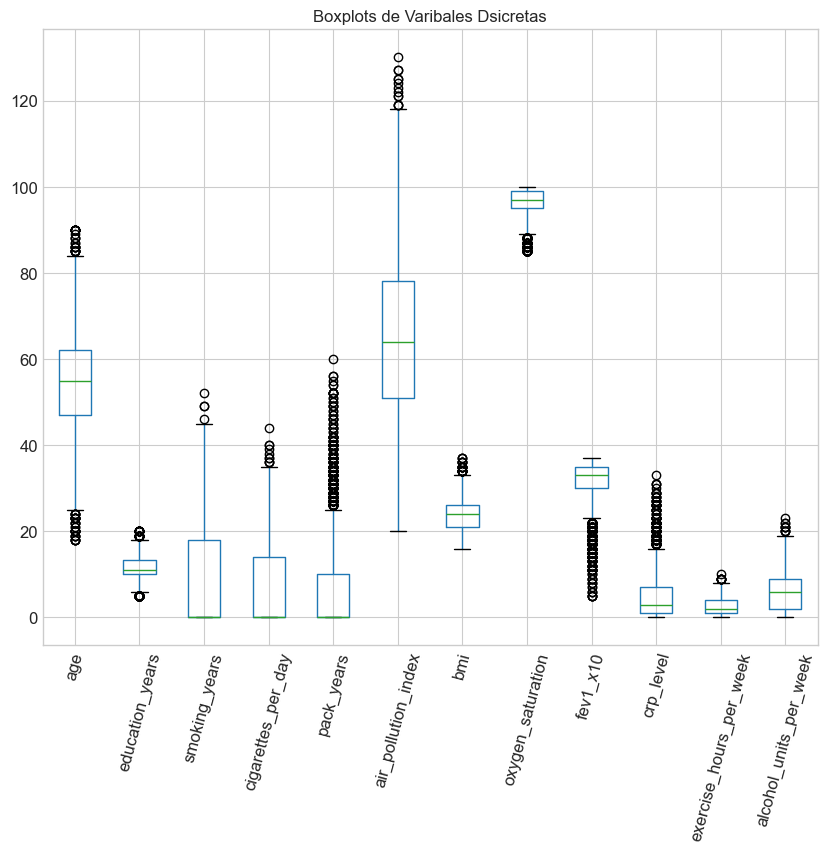

```python
plt.figure(figsize=(10,8))
disc_df.boxplot(fontsize=12, rot=75)
plt.title('Boxplots de Varibales Dsicretas')
plt.show()
```

Mediante la visualización anterior, se corrobora que las variables relacionadas con el tabaco `smoking_years`,`cigarrettes_per_day` y `pack_years`, tienen un valor de mediana (*Q2* = 0) muy diferente del valor de la media, debido a la presencia de *outliers*.

Se observa que las variables con más outliers, `pack_years`,`fev1_x10` y `crp_level`, también son las que tienen un valor mas alto de *kurtosis*, así como una diferencia clara entre *Min* y *Q1* o *Q3* y *Max*, representando colas pesadas y valores atípicos en la distribución.

A pesar de que en variables como `age`, `education_years`, `bmi` y `airpollution_index`, las cuales se había comentado anteriormente que seguian mas o menos una distribución normal, muestren *outliers* en su diagrama de caja (*boxplot*), eso no quiere decir que sean explícitamente valores atípicos, ya que por ejemplo no és poco común tener 20 o 90 años, simplemente hay menos instancias con esos valores en la muestra (*dataset*)

En este *dataset* en concreto, a pesar de la presencia clara de **outliers**, **no** sería buena idea **eliminarlos**, ya que de esta forma estaríamos limitando la capacidad del estudio inferencial o modelo predictivo para identificar **casos de alto riesgo**. Una buena estrategia sería estandarizar los datos o usar modelos menos sensibles a *outliers* como arboles de decision.

- En caso de usar un modelo sensible a outliers debemos tener en cuenta que la presencia de los mismos causará **inflación de la media** así como de la **desviación estándar**, afectando negativamente a tests de hipótesis los cuales asumen normalidad (Tests Paramétricos).

#### 1.5. **Visualización de Distribuciones:**

A continuación se determinará si las observaciones comentadas a cerca de las distribuciones de las diferentes variables discretas realmente concuerdan con su histograma.

**Variables Discretas**

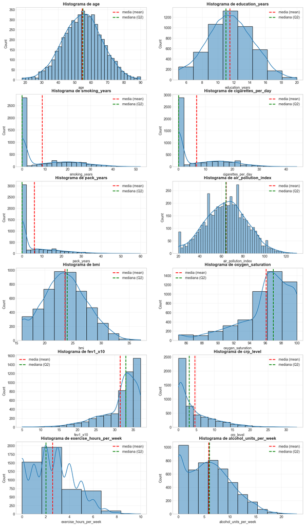

```python
fig, axes = plt.subplots(10, 2, figsize=(15, 45))
axes = axes.flatten()  # Flatten for easy iteration

for i, col in enumerate(disc_df.columns):
    unique_count = df[col].nunique()
    bins = max(6, unique_count // 2)  # dynamic bin number for clarity

    sns.histplot(disc_df[col], ax=axes[i], bins=bins, kde=True)
    axes[i].axvline(x=disc_describe.loc[col, 'mean'], label = 'media (mean)', color='red', linewidth = 2, linestyle='--')
    axes[i].axvline(x=disc_describe.loc[col, '50%'], label = 'mediana (Q2)', color='green', linewidth = 2, linestyle='--')
    axes[i].set_title(f'Histograma de {col}', fontsize=12, fontweight='bold')
    axes[i].grid(True, alpha=0.3)
    axes[i].set_xlabel(col)
    axes[i].legend()

# Hide unused subplots
for i in range(len(disc_df.columns), len(axes)):
    axes[i].set_visible(False)

plt.show()
```

Gracias a los histogramas anteriores, se corrobora la información y observaciones de la sección `1.3 Estadísticos Descritivos` acerca de las variables discretas.

En la sección `1.3` se comentó que las variables siguientes tenian una distribución parecida a una distribución normal:

- `Age` (Edad)
- `Education Years` (Años de Eduacación)
- `Air Pollution Index` (Índice de contaminación del aire)
- `bmi` (Índice de Masa Corporal)

Es decir:

- Media $\approx$ mediana
- *Skewness* cercano a 0
- *Kurtosis* cercana a 0
- Dispersión y valores extremos coherente con su contexto
- Ausencia de colas extremas u valores atípicos problemáticos

Se observa claramente que la distribución que más se acerca a una distribución normal corresponde a la variable `age`, las otras tres variables tienen una ligera asimetría positiva.

Por otro lado también se corrobora que las **variables relacionadas con el tabaco**:

- `Smoking Years`
- `Cigarettes per Day`
- `Pack Years`

Tienen distribuciones muy parecidas, resultado coherente con el contexto de las variables.

Seguidamente:

- `Oxygen Saturation` (Nivel % de oxígeno en sangre)
- `FEV1_x10` (Volumen de aire Exhalado durante 1 segundo)
- `CRP Level` (Nivel de proteína C reactiva, indicador de inflamación sistémica)

También tienen mucho sesgo, el motivo, como se ha comentado en la sección `1.3` es similar a las variables de consumo de tabaco. Los individuos sanos se centran en un rango en específico, mientras que los individuos de riesgo o simptomas se distribuyen a lo largo de un rango más amplio, provocando asímetria negativa en el caso de `oxygen_saturation` y `FEV1_x10` o positiva en el caso de `CRP Level`.

Finalmente también se corrobora que

`Exercise Hours per Week` y `Alcohol Units per Week` Presentan distribuciones muy similares, provocado por patrones de comportamiento humanos similares.

## PARTE 2: Inferencia y Modelado (Dataset Propio)

**Objetivo:** Descubrir relaciones entre variables y predecir resultados.

**Requisitos:**

1. **Análisis de Correlación:** Genera una matriz de correlación y visualízala con un Heatmap. ¿Qué variables están más relacionadas con tu Target?
2. **Relaciones Bivariantes:** Crea Scatter Plots para visualizar la relación entre las variables independientes más fuertes y tu variable objetivo.
3. **Regresión Lineal (Scikit-Learn):**
   - Selecciona tus variables predictoras ($X$) y tu objetivo ($y$).
   - Realiza un Train/Test Split (80/20).
   - Entrena un modelo de Regresión Lineal.
   - Evalúa el modelo usando **R²** y **RMSE**.
4. **Regresión logistica:**
   - Selecciona tus variables predictoras ($X$) y tu objetivo ($y$).
   - Realiza un Train/Test Split (80/20).
   - Entrena un modelo de Regresión Lineal.
   - Evalúa el modelo usando **R²** y **RMSE**.

**📝 Conclusión:** ¿Es tu modelo capaz de predecir con precisión? ¿Qué variables son las más influyentes?¿Qué tipo de regresión es la más apropiada?

Amplía el análisis incorporando los siguientes aspectos:

- **Diagnóstico del modelo de regresión lineal** Analiza los residuos del modelo entrenado:
  - Distribución de los residuos
  - Relación entre residuos y valores predichos  
    Comenta si se cumplen los supuestos básicos del modelo.
- **Regresión logística: adecuación del modelo** Justifica si la regresión logística es apropiada para tu variable objetivo y discute las diferencias conceptuales con la regresión lineal.
- **Comparación de modelos** Compara brevemente el rendimiento y la idoneidad de ambos enfoques (lineal vs. logístico) más allá de las métricas numéricas.

#### 2.1. **Análisis de Correlación:**

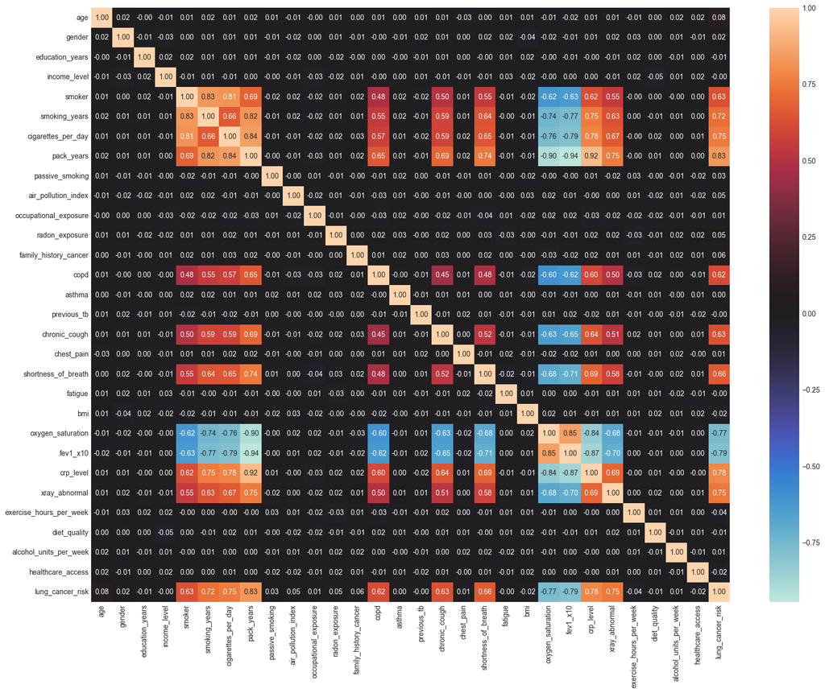

```python
plt.figure(figsize=(20, 15))
sns.heatmap(df.corr(), annot=True, fmt='.2f', cmap='icefire')
plt.show()
```

De las 30 varibales totales del *dataset* se observa que solamente 12 tienen correlaciones con otras variables, concretamente todas esas 12 variables tienen correlaciones con las otras 11 variables:

**Variables Binarias**

- `smoker`
- `copd`
- `chronic_cough`
- `shortness_of_breath`
- `xray_abnormal`
- `lung_cancer_risk`

**Variables Discretas**

- **Variables relacionadas con el tabaco**
  - `smoking_years`
  - `cigarettes_per_day`
  - `pack_years`
- **Variables de medidas clínicas**
  - `oxygen_saturation`
  - `fev1_x10`
  - `crp_level`

Claramente se observa que no hay correlación entre la variable objetivo `lung_risk_cancer` con las varibales numericas ordinales: `income_level`, `diet_quality` y `healthcare_acces`, pero para estar estadísticamente seguros de la variable objetivo es independiente de estas variables se deberá realizar un test de hipótesis

**Comparativa entre variables categoricas y varibale objetivo**

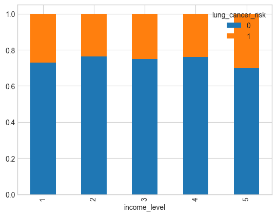

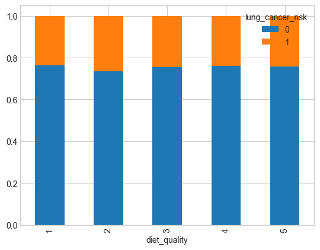

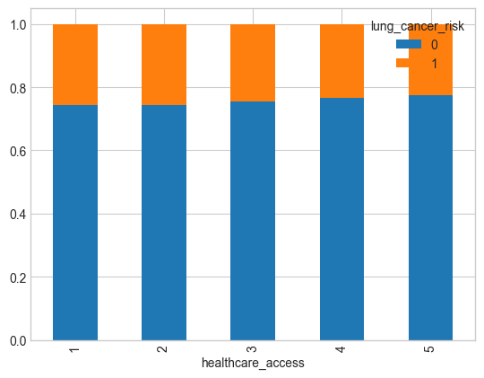

```python
df.groupby('income_level')['lung_cancer_risk'].value_counts(normalize=True).unstack().plot(kind='bar', stacked=True)
plt.show()

df.groupby('diet_quality')['lung_cancer_risk'].value_counts(normalize=True).unstack().plot(kind='bar', stacked=True)
plt.show()

df.groupby('healthcare_access')['lung_cancer_risk'].value_counts(normalize=True).unstack().plot(kind='bar', stacked=True)
plt.show()
```

A simple vista, en ninguna de las variables categoricas, parece haber distincción en cuanto a individuos de riesgo a cancer entre categorias. Para confirmarlo estadísticamente se debería hacer un test de hipotesis para desmentir o corroborar si la hipótesis nula (***H0*: No hay diferencia entre categorias**) es cierta.

- En este caso se debería usar un test de independencia **Chi-Square** ($\chi^2$), para determinar si la variable objetivo `lung_cancer_risk` es independiente de cada ua de las variables categoricas (`income_level`, `diet_quality` y `healthcare_access`) (*H0*) o si **no** son independientes, hipótesis alternativa (*HA*)

**A continuación se realiza una prueba para la variable que parece tener más diferencia entre categorias que las demás: `income_level`**

- Se define $\alpha$ = 0.05 (Nivel de significación)
- Para corroborar la idea de que hay independencia entre la variable objetivo `lung_cancer_risk` y `income_level` (*H0*), se deberá obtener *p-values* meayores al nivel de significación, por lo contrarió la hipótesis nula queda rechazada, aceptando la alternativa y por ende demostrando que hay **dependencia** entre variable objetivo y vbariable categorica.

**Definiciones:**

- $\alpha$ (Nivel de significación): Máximo riesgo que se está dispuesto a correr para aceptar el rechazo de la hipótesis nula.
- *p-value*: Indica la probabilidad de observar resultados igual de extremos o más a los resultados obtenidos asumiendo que la hipótesis nula (*H0*) es cierta.

```python
excepted, observed, statistics = chi2_independence(data=df, x='lung_cancer_risk', y='income_level', correction=False)
display(statistics)
```

|  | test | lambda | chi2 | dof | pval | cramer | power |
| --- | --- | --- | --- | --- | --- | --- | --- |
| 0 | pearson | 1.000000 | 5.407655 | 4.0 | 0.247967 | 0.032887 | 0.426700 |
| 1 | cressie-read | 0.666667 | 5.372275 | 4.0 | 0.251187 | 0.032779 | 0.424071 |
| 2 | log-likelihood | 0.000000 | 5.305465 | 4.0 | 0.257366 | 0.032574 | 0.419094 |
| 3 | freeman-tukey | -0.500000 | 5.258653 | 4.0 | 0.261773 | 0.032430 | 0.415600 |
| 4 | mod-log-likelihood | -1.000000 | 5.214522 | 4.0 | 0.265986 | 0.032294 | 0.412300 |
| 5 | neyman | -2.000000 | 5.133825 | 4.0 | 0.273840 | 0.032043 | 0.406253 |

Para este proyecto solamente nos centraremos en la columna de **pval**.

#### 2.2. **Relaciones Bivariantes:**

Para visualizar estas relaciones solamente se seleccionarán las variables discretas con mayor correlacion respecto a la variable objetivo `lung_cancer_risk`. No se seleccionan las variables binarias con correlación ya que en una visualización de `pairplot` las relaciones binarias menos informativas.

Así mismo como suprimiendo variables las cuales su información es redundante, como por ejemplo: `smoker` (0 = No Fumador, 1 = Fumador) y `pack_years` (número de paquetes de tabaco al año) por las variables `smoking_years` la cual nos informa de la duración y `cigarettes_per_day` que nos informa de la cantidad de forma más precisa.

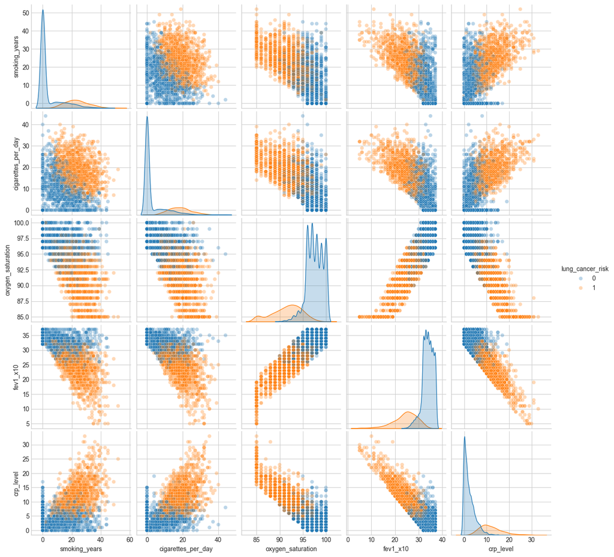

```python
bin_corr = ['copd', 'chronic_cough', 'shortness_of_breath', 'xray_abnormal']
corr_variables = ['smoking_years', 'cigarettes_per_day', 'oxygen_saturation', 'fev1_x10', 'crp_level', 'lung_cancer_risk']

corr_df = df[corr_variables]

sns.pairplot(corr_df, hue='lung_cancer_risk', plot_kws={'alpha': 0.3})
plt.show()
```

**Variables relacionadas con el tabaco**

- Los individuos con alto riesgo de cáncer de pulmón se concentran en regiones donde coinciden valores elevados de:
  - `smoking_years`
  - `cigarettes_per_day`
- Cuando solo una de las dos variables es alta y la otra baja, la presencia de casos positivos es mucho menor.
- Esto sugiere que el riesgo es **acumulativo (duración × intensidad)**.

**Variables de medidas clínicas**

- **`fev1_x10` (Función pulmonar)**
  - Existe una relación negativa clara entre consumo de tabaco y función pulmonar.
  - Los valores bajos de `fev1_x10` están dominados por individuos con `lung_cancer_risk = 1`.
- **`crp_level` (Inflamación)**
  - Aumenta con el historial de consumo de tabaco (inflamación acumulada).
  - Los valores altos de CRP están mayoritariamente asociados a alto riesgo de cáncer.
- **`oxygen_saturation` (Saturación de oxígeno)**
  - Se observa una separación clara:
    - Saturaciones bajas, mayor presencia de `lung_cancer_risk = 1`
    - Saturaciones normales, predominio de `lung_cancer_risk = 0`
  - Combinada con `fev1_x10`, ofrece una fuerte capacidad discriminativa.

El riesgo de cáncer de pulmón emerge de la **interacción entre exposición prolongada y respuesta fisiológica**. Las variables clínicas (`fev1_x10`, `oxygen_saturation`, `crp_level`) son las más discriminativas.

Según las relaciones observadas en el pairplot, sugiere que modelos con un **enfoque no lineal** capturarán mejor la estructura del problema.

#### 2.3. **Regresión Lineal (Scikit-Learn):**

**Inferencia vs Predicción**

Antes de plantear como entrenar el modelo, hay que tener claro el objetivo del estudio.

- **Inferencia**: El objetivo en la inferencia es entender como las variables seleccionadas afectan a la variable de respuesta mediante la interpretación de los coeficientes del modelo, tests de hipótesis, p-values, etc. La inferencia responde a preguntas como:
  - ¿Que variables estan más relacionadas con la variable de respuesta (variable objetivo)?
  - ¿Cuál es la dirección y magnitud de esta relación?
  - ¿Las relaciones son estadísticamente significativas? Para escoger un modelo para hacer inferencia, hay que priorizar interpretabilidad antes que precisión.
- **Predicción**: El objetivo de la predicción es minimizar el error predictivo sobre datos jamás vistos por el modelo. La predicción responde a preguntas como:
  - ¿Que precisión obtuvo el modelo?
  - ¿El modelo generaliza bien para datos nuevos? En la predicción es más común sacrificar interpretabilidad por precisión y buena generalización.

*A pesar de que hacer un **estudio predictivo** no es el objetivo de este módulo de estdística, a continuación se realizaran ambas técnicas para comprender la distinta metodologia y objetivos. Para obtener una buena comparación entre métodos, se usaran las misams variables*

**INFERENCIA**

Para esta sección se **estudiará la relación** entre las variables `fev1_x10` y `crp_level`, cuya correlación és del **-0.87**.  
No se usará la variable objetivo ya que esta es de carácter binario, en este caso se estaría hablando de un problema de **clasificación**, no de **regressión**, y además no cumpliria la primera, y más importante, suposición de los modelos de regressión lineal, la cual és linealidad entre variable explicativa y lavariable de respuesta. Forzar un modelo de regresión lineal en ese contexto produciría resultados engañosos y difícilmente interpretables.

A continuación se simulará un estudio donde `fev1_x10` será la variable de respuesta y `crp_level` será la variable explicativa, on el objetivo de evaluar si existe una **relación estadísticamente significativa** entre la inflamación y la función pulmonar, así como cuantificar la magnitud y dirección de dicha relación.

Se evaluarán métricas y estadísticos propios del análisis inferencial, tales como:

- Coeficientes del modelo (intercepto y pendiente), para interpretar la relación entre las variables.
- **Errores estándar**: Cuantifican la variabilidad de los estimadores.
- **p-values**: Contrastar hipótesis sobre la significancia estadística de los coeficientes.
- **Intervalos de confianza**: Permiten evaluar la robustez de las estimaciones.
- **$R^2$ (R_squared)**: Como medida descriptiva de la proporción de varianza explicada (no como métrica de optimización).

En este caso no será necesario escalar los datos, ya que ambas variables se encuentran en una escala comparable. No obstante, en modelos multivariantes o con variables en escalas distintas, el escalado sería recomendable mediante técnicas como *MinMaxScaler* o *StandardScaler*.

```python
X_inf = disc_df[['crp_level']]
y_inf = disc_df['fev1_x10']

# Añadir constante para el intercepto
X_inf = sm.add_constant(X_inf)

ols_model = sm.OLS(y_inf, X_inf).fit()

print(ols_model.summary())
```

```
                            OLS Regression Results
==============================================================================
Dep. Variable:               fev1_x10   R-squared:                       0.765
Model:                            OLS   Adj. R-squared:                  0.765
Method:                 Least Squares   F-statistic:                 1.629e+04
Date:                Sun, 08 Feb 2026   Prob (F-statistic):               0.00
Time:                        11:37:23   Log-Likelihood:                -11728.
No. Observations:                5000   AIC:                         2.346e+04
Df Residuals:                    4998   BIC:                         2.347e+04
Df Model:                           1
Covariance Type:            nonrobust
==============================================================================
                 coef    std err          t      P>|t|      [0.025      0.975]
------------------------------------------------------------------------------
const         35.4038      0.047    750.780      0.000      35.311      35.496
crp_level     -0.8551      0.007   -127.636      0.000      -0.868      -0.842
==============================================================================
Omnibus:                      363.106   Durbin-Watson:                   2.003
Prob(Omnibus):                  0.000   Jarque-Bera (JB):              542.025
Skew:                           0.590   Prob(JB):                    2.00e-118
Kurtosis:                       4.099   Cond. No.                         9.37
==============================================================================

Notes:
[1] Standard Errors assume that the covariance matrix of the errors is correctly specified.
```

**Coeficiente (`crp_level`)**

**Error estándar**

- El error estándar asociado al coeficiente es 0.007, lo que indica una estimación muy precisa del efecto de `crp_level`.
- Un error estándar pequeño en relación con la magnitud del coeficiente sugiere que la variabilidad del estimador es baja y que el efecto está bien identificado en la muestra.

**Significancia estadística (p-value)**

- El valor **p < 0.001**, muy por debajo de cualquier nivel de significación habitual (por ejemplo, **$\alpha$ = 0.05**).
- Esto permite rechazar la hipótesis nula de que no hay relación entre variables (coeficiente = cero) . Por tanto, existe evidencia estadística suficiente para afirmar que `crp_level` está significativamente asociado con `fev1_x10`.

**Intervalo de confianza (95%)**

- El intervalo de confianza al 95% para el coeficiente es [−0.868, −0.842].
- Este intervalo no contiene el valor cero, lo que refuerza la conclusión de significancia estadística.
- Además, el intervalo es estrecho, lo que confirma nuevamente la precisión de la estimación.

**Coeficiente de determinación ($R^2$)**

- El valor **$R^2 = 0.765$** indica que el modelo es capaz de explicar aproximadamente el 76.5% de la variabilidad observada en `fev1_x10` a partir de `crp_level`.
- Este valor es elevado para un modelo univariante, lo que sugiere una relación fuerte y estructurada entre ambas variables.

**PREDICCIÓN**

Una vez analizada la relación entre `fev1_x10` y `crp_level` desde un enfoque **inferencial**, se plantea ahora un estudio con un objetivo distinto: **la predicción**. En este contexto, el interés principal reside en cuantificar la capacidad del modelo para generalizar y realizar predicciones precisas sobre datos no vistos.

En este estudio, se mantiene el uso de un modelo de regresión lineal, ya que la variable de respuesta `fev1_x10` es discreta y existe una relación aproximadamente lineal con `crp_level`. No se utiliza la variable objetivo binaria del dataset, ya que, como se ha comentado, su modelización correspondería a un problema de clasificación. Para solucionar un problema de clasificación usando un modelo lineal, se usan modelos como **Support Vector Machines (SVM)**

Para evaluar el desempeño predictivo del modelo entrenado, se utilizarán métricas orientadas al error, que permiten cuantificar la calidad de las predicciones como *RMSE* y *R_squared*, calculada anteriormente.

Para obtener más información a cerca del rendimiento del modelo entrenado, se añadiran también las siguientes métricas:

- **mean_absolute_error (*MAE*)**: Mide el error absoluto promedio de las predicciones, ismas unidades que la variable de respuesta.
- **mean_absolute_percentage_error (*MAPE*)**: Mide el % de error absoluto promedio de las predicciones.

```
Intercept 35.4060
Slope -0.8515
RMSE 2.3929
R_Squared 0.7941
MAE 1.8858
MAPE 0.0673
```

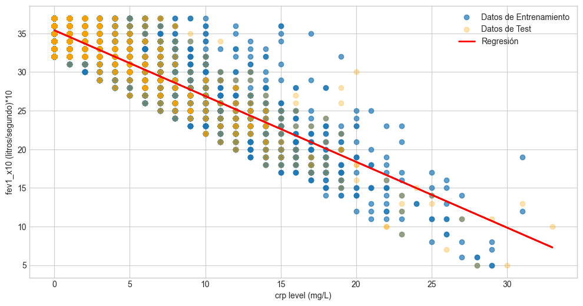

```python
X = disc_df[['crp_level']]
y = disc_df[['fev1_x10']]

X_train, X_test, y_train, y_test = train_test_split(X, y, test_size=0.2, random_state=1)

# Scikit-Learn
lr_model = LinearRegression()
lr_model.fit(X_train,y_train)

# Parámetros aprendidos
a0 = lr_model.intercept_[0]
a1 = lr_model.coef_[0][0]

# Predicciones
y_pred = lr_model.predict(X_test)

# Métricas
rmse = mean_squared_error(y_test, y_pred)**(1/2)
r2 = r2_score(y_test, y_pred)
mae = mean_absolute_error(y_test, y_pred)
mape = mean_absolute_percentage_error(y_test, y_pred)

print(f'Intercept {a0:.4f}')
print(f'Slope {a1:.4f}')
print(f'RMSE {rmse:.4f}')
print(f'R_Squared {r2:.4f}')
print(f'MAE {mae:.4f}')
print(f'MAPE {mape:.4f}')

plt.figure(figsize=(12,6))
plt.scatter(X_train, y_train, label='Datos de Entrenamiento', alpha=0.7)
plt.scatter(X_test, y_test, label='Datos de Test', color='orange', alpha=0.3)
plt.plot(X_test, y_pred, color='red', linewidth=2, label='Regresión')
plt.legend()
plt.xlabel('crp level (mg/L)')
plt.ylabel('fev1_x10 (litros/segundo)*10')
plt.show()
```

Interpretando los resultados obtenidos de la regresión:

- **Pendiente (*Slope*) = -0.8515**
  - El valor de la pendiente es prácticamente idéntico al obtenido en el modelo de inferencia ($\approx$ −0.855), lo que indica que la relación estimada entre `crp_level` y `fev1_x10` es estable y consistente, independientemente del enfoque utilizado.
  - Esta similitud sugiere que el modelo no está sobreajustado al conjunto de entrenamiento y que la relación lineal general se mantiene en datos no vistos.
- **R_squared ($R^2$) = 79,41%**
  - El modelo es capaz de explicar 79% de la varianza de la función pulmonar (`fev1_x10`) a partir de la información de la inflamación (`crp_level`), indicando que hay un 21% restante posiblemente atribuible a otros factores (incluidos, o no, en el *dataset*).
  - Este valor es ligeramente superior al obtenido en el modelo de inferencia ($R^2 \approx 76.5%$), lo cual es esperable al evaluar el rendimiento sobre un subconjunto distinto (y mas pequeño, conjunto de test < todos los datos) de los datos.
- **RMSE = 2.3929**
  - Indica que, en promedio, las predicciones del modelo se desvían $\approx$ 2.39 unidades (mismas unidades que la variable de respuesta) respecto a los valores reales de `fev1_x10`.
  - El *RMSE* penaliza más los errores grandes.
- **MAE (Mean Absolute Error) = 1.8858**
  - Indica que, en promedio, las predicciones del modelo se desvían $\approx$ 1.89 unidades respecto a los valores reales de `fev1_x10`.
  - Al ser una métrica en las mismas unidades que la variable de respuesta, su interpretación es directa y complementa al RMSE.
  - El hecho de que el MAE sea menor que el RMSE sugiere que los errores grandes son poco frecuentes, y que el modelo no está dominado por valores extremos.
- **MAPE (Mean Absolute Percentage Error) = 6.73%**
  - Significa que, en promedio, el error del modelo representa solo un 6.7% del valor real de la función pulmonar (`fev1_x10`).
  - Este valor indica un buen desempeño relativo, especialmente útil para evaluar la calidad del modelo de forma independiente de la escala de la variable.

En conjunto, MAE, RMSE y MAPE refuerzan la idea de que el modelo presenta buena capacidad predictiva, con errores moderados y consistentes, alineados con el alto valor de $R^2$ obtenido.

**Comparación entre Inferencia y Predicción**

A pesar de utilizar las mismas variables (crp_level → fev1_x10), los objetivos de inferencia y predicción son distintos, recordar que:

**En inferencia**, el foco está en:

- Estimar el efecto medio de crp_level sobre fev1_x10.
- Evaluar la significancia estadística del coeficiente mediante p-values, intervalos de confianza y errores estándar.
- Extraer conclusiones sobre la existencia, dirección y magnitud de la relación entre variables.

**En predicción**, el objetivo es:

- Evaluar cómo de bien el modelo generaliza a datos no vistos.
- Medir el desempeño mediante métricas de error como RMSE, MAE y MAPE.
- Priorizar precisión y estabilidad predictiva sobre interpretabilidad estadística.

El hecho de que la pendiente y el $R^2$ sean muy similares en ambos enfoques refuerza la robustez del modelo y confirma que la relación identificada es tanto estadísticamente significativa como predictivamente útil.

**COMPROBACIÓN DE LAS SUPOSICIONES**

- **Linealidad**
- **Normalidad en los Errores**
- **Independecia de los Errores**
- **Varianza Constante en los Errores**

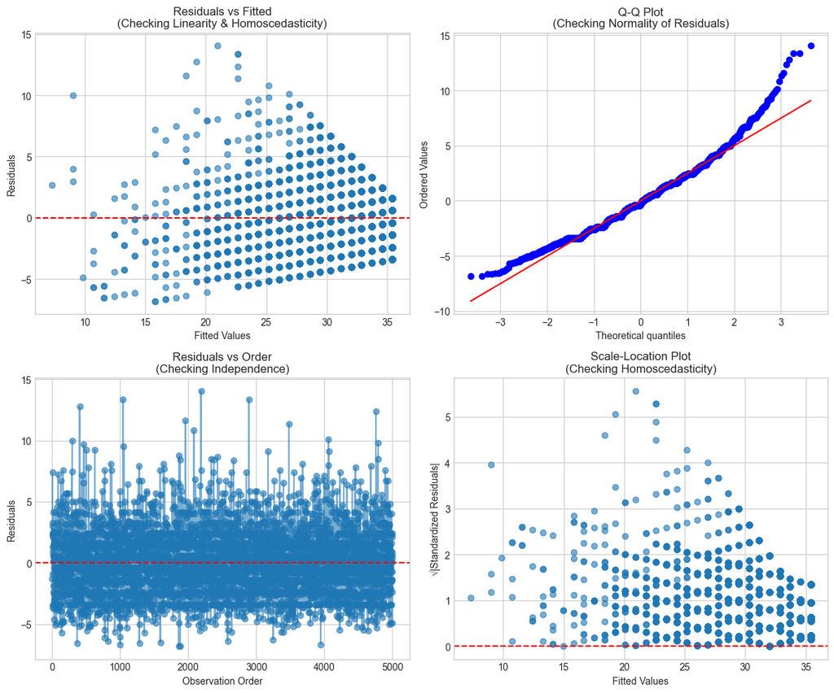

```
STATISTICAL TESTS FOR ASSUMPTIONS

Shapiro-Wilk normality test: p-value = 0.0000
Correlation between fitted and squared residuals: -0.3035 (p=0.0000)
Durbin-Watson statistic: 2.0029
```

```python
# residuos
y_inf_pred = lr_model.predict(X)
residuals = y.values - y_inf_pred

#Paso necesario de conversion a pd.Series
y_inf_pred_series = pd.Series(y_inf_pred.ravel(), name='y_pred')
residuals = pd.Series(residuals.ravel(), name='residuals')


fig, axes = plt.subplots(2, 2, figsize=(12, 10))

# 1. Linearity: Residuals vs Fitted
axes[0,0].scatter(y_inf_pred_series, residuals, alpha=0.6)
axes[0,0].axhline(y=0, color='red', linestyle='--')
axes[0,0].set_xlabel('Fitted Values')
axes[0,0].set_ylabel('Residuals')
axes[0,0].set_title('Residuals vs Fitted\n(Checking Linearity & Homoscedasticity)')

# 2. Normality: Q-Q Plot
stats.probplot(residuals, dist="norm", plot=axes[0,1])
axes[0,1].set_title('Q-Q Plot\n(Checking Normality of Residuals)')

# 3. Independence: Residuals vs Order
axes[1,0].plot(residuals, 'o-', alpha=0.6)
axes[1,0].axhline(y=0, color='red', linestyle='--')
axes[1,0].set_xlabel('Observation Order')
axes[1,0].set_ylabel('Residuals')
axes[1,0].set_title('Residuals vs Order\n(Checking Independence)')

# 4. Homoscedasticity: Scale-Location Plot
standardized_residuals = np.abs(residuals / np.std(residuals))
axes[1,1].scatter(y_inf_pred_series, standardized_residuals, alpha=0.6)
axes[1,1].axhline(y=0, color='red', linestyle='--')
axes[1,1].set_xlabel('Fitted Values')
axes[1,1].set_ylabel('√|Standardized Residuals|')
axes[1,1].set_title('Scale-Location Plot\n(Checking Homoscedasticity)')

plt.tight_layout()
plt.show()

# ASUMCIONES
print("STATISTICAL TESTS FOR ASSUMPTIONS\n")

# Normality test (Shapiro-Wilk)
shapiro_stat, shapiro_p = stats.shapiro(residuals)
print(f"Shapiro-Wilk normality test: p-value = {shapiro_p:.4f}")

# Homoscedasticity test (Breusch-Pagan would be better, but simpler approach)
# Check correlation between fitted values and squared residuals
corr_coef, corr_p = stats.pearsonr(y_inf_pred_series, residuals**2)
print(f"Correlation between fitted and squared residuals: {corr_coef:.4f} (p={corr_p:.4f})")

# Independence (Durbin-Watson)
dw_stat = durbin_watson(residuals)
print(f"Durbin-Watson statistic: {dw_stat:.4f}")
```

**Normalidad de los residuos (Test Shapiro-Wilk)**

El test de Shapiro–Wilk indica que los residuos no siguen una distribución normal (p-value ≈ 0).

- **Impacto en inferencia**
  - La normalidad de los residuos es clave para que los errores estándar, los intervalos de confianza, y los p-values sean estadísticamente fiables.
  - Al no cumplirse esta asunción, los p-values y los intervalos de confianza pueden estar sesgados, especialmente en muestras pequeñas.
  - En este caso concreto, el tamaño muestral es grande (n = 5000), por lo que, gracias al **Teorema Central del Límite**, el impacto práctico sobre la inferencia es limitado, aunque debe mencionarse.
- **Impacto en predicción**
  - La normalidad de los residuos no es un requisito para que el modelo prediga bien.
  - Por tanto, esta violación no afecta de forma directa a métricas como RMSE, MAE o MAPE, ni a la capacidad predictiva observada.

**Varianza constante de los residuos (Homoscedasticidad)**

La correlación negativa observada indica heterocedasticidad, es decir, la varianza del error cambia a lo largo del rango de predicción.

- **Impacto en inferencia**
  - La heterocedasticidad provoca errores estándar incorrectos, intervalos de confianza mal estimados, y p-values potencialmente engañosos.
  - Esto significa que, aunque el coeficiente estimado siga siendo insesgado, la confianza estadística asociada a dicho coeficiente puede estar mal cuantificada.
- **Impacto en predicción**
  - La heterocedasticidad no invalida las predicciones, pero sí implica que: el modelo comete errores más grandes en ciertas regiones del espacio de predicción.
  - Esto es coherente con la diferencia observada entre RMSE y MAE, indicando que existen errores más grandes en ciertos rangos de crp_level.

**Independencia de los errores (Test Durbin-Watson)**

El estadístico de Durbin–Watson ≈ 2 confirma que los errores son independientes.

- **Impacto en inferencia**
  - La independencia de los errores es una de las asunciones más críticas.
  - Al cumplirse, los coeficientes estimados son consistentes y las inferencias no están contaminadas por autocorrelación.
- **Impacto en predicción**
  - La independencia también favorece una buena generalización del modelo.
  - En este contexto, confirma que el error en una observación no depende del error en otra.

**Conclusión Inferencia y Predicción**

Las violaciones de las suposiciones afectan principalmente a la inferencia estadística, es decir, a la interpretación formal de p-values, intervalos de confianza y errores estándar.

Sin embargo, no comprometen de forma significativa la capacidad predictiva del modelo, como lo confirman los valores de RMSE, MAE, MAPE y $R^2$.

La independencia de los errores, al cumplirse, refuerza tanto la validez del modelo inferencial como su estabilidad predictiva.

En conjunto, el modelo es válido y coherente para predicción, mientras que para inferencia los resultados son interpretables, pero deben considerarse con cautela o complementarse con técnicas robustas.

#### 2.4. **Regresión logistica:**

A pesar de su nombre, la **Regresión Logistica** es un modelo de **clasificación**, no de **regresión**, por lo que en este caso si podemos predecir sobre la variable objetivo `lung_cancer_risk`.

Donde la probabilidad de que una instancia de positivo en la variable objetivo, viene dada por:

$$y = \frac{e^{\beta_0 + \beta_1 X}}{1 + e^{\beta_0 + \beta_1 X}}$$

Siendo $\beta_0$ el intercepto y $\beta_1$ la pendiente.

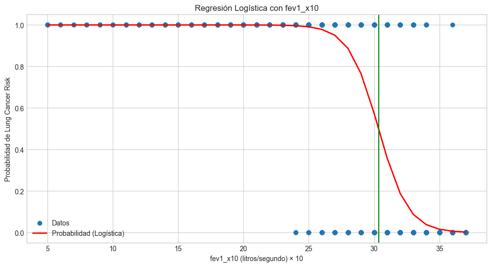

```python
# Variables
X_log = disc_df[['fev1_x10']]
y_log = bin_df['lung_cancer_risk']  # Series, no DataFrame

# Train / Test
X_train_log, X_test_log, y_train_log, y_test_log = train_test_split(
    X_log, y_log, test_size=0.3, random_state=1
)

# Modelo con balanceo de clases (ya que la variable objetivo está desbalanceada)
log_mdl = LogisticRegression(class_weight='balanced')
log_mdl.fit(X_train_log, y_train_log)

# Predicciones
y_pred_log = log_mdl.predict(X_test_log)
y_prob_log = log_mdl.predict_proba(X_test_log)[:, 1]


# Ordenar para dibujar la curva correctamente
order = np.argsort(X_test_log.values.flatten())
X_sorted = X_test_log.values.flatten()[order]
y_prob_sorted = y_prob_log[order]

# Plot
plt.figure(figsize=(12,6))

plt.scatter(X_log, y_log, label='Datos')
plt.plot(X_sorted, y_prob_sorted, color='red', linewidth=2, label='Probabilidad (Logística)')
plt.axvline(x=30.35, color = 'green')
plt.xlabel('fev1_x10 (litros/segundo) × 10')
plt.ylabel('Probabilidad de Lung Cancer Risk')
plt.legend()
plt.title('Regresión Logística con fev1_x10')
plt.show()
```

La línea roja de la figura anterior respresenta la probabilidad de cada individuo según su valor de `fev1_x10` de padecer cáncer de pulmón. Se observa que la frontera de decisión entre individuos con `lung_cancer_risk = 1` y `lung_cancer_risk = 0` se encuentra aproximadamente en un valor de `fev1_x10` de 30 litros/segundo*10 (línea verde vertical), eso quiere decir que el modelo atribuye una **probabilidad mayor de 50% de padecer cáncer** a aquellos individuos que tengan un valor menor al mencionado.

En este caso no tiene sentido evaluar el modelo usando métricas para modelos de regressión como lo son: `RMSE` y `R_Squared`, ya que el modelo de **Regresión Logística** no predice valores numéricos, sino probabilidades de pertenecer a la clase objetivo.

Para los problemas de **clasificación** existen otras métricas de evaluación de modelos, la mayoría basadas en 4 valores (Teniendo en cuenta que el objetivo es predecir con exito `lung_cancer_risk = 1`):

- **Positivos Reales (TP)**: Individuos de la Clase 1 predecidos como Clase 1
- **Negativos Reales (TN)**: Individuos de la Clase 0 predecidos como Clase 0
- **Positivos Falsos (FP)**: Individuos de la Clase 0 predecidos como Clase 1
- **Neagtivos Falsos (FN)**: Individuos de la Clase 1 predecidos como Clase 0

Estos 4 valores forman la llamada **Matriz de Confusión**

|  | Real 0 | Real 1 |
| --- | --- | --- |
| **Predicción 0** | TN | FN |
| **Predicción 1** | FP | TP |

Las metricas de evlauación más comunes son:

Hay otras métricas como las **specificity** o **ROC-AUC**, pero con las anteriores es más que suficiente en este caso.

Para saber que metricas usar en este caso se debe tener en cuenta que la variable objetivo está **desbalanceada** (75% Clase 0 vs 25% Clase 1), por lo que usar la *Accuracy* como referencia no es una buena idea, ya que esta mide todos los aciertos indistintivamente de la clase, por lo que un valor alto de *Accuracy* puede infromar que el modelo capta bien los individuos sanos (la mayoría) pero no los otros.  
En este contexto se necesita un balance entre *Precision* y *Recall*, ja que queremos el menor número de **falsos positivos** así como el menor número de **falsos negativos** possible.

```python
precision_fev1 = precision_score(y_test_log, y_pred_log)
recall_fev1 = recall_score(y_test_log, y_pred_log)
f1_score_fev1 = f1_score(y_test_log, y_pred_log)

print(f'Precision: {precision_fev1:.4f}')
print(f'Recall: {recall_fev1:.4f}')
print(f'F1 Score: {f1_score_fev1:.4f}')
```

```
Precision: 0.8090
Recall: 0.8979
F1 Score: 0.8511
```

Con tan solo una variable, `fev1_x10`, el modelo es capaz de detectar un 89,79% de los individuos de clase 1, `lung_cancer_risk = 1`, y de todos los individuos predichos como propensos a riesgo un 80% realmente lo son mientras que el 20% restante son **Falsos positivos**.

Para obtener incluso mejores resultados, se deberá hacer una regresión logística con todas las variables del *dataset*. Para determinar que variables son realmente essenciales para el modelos se deberán comprovar la contribución de cada **coeficiente**, si estos son pequeños indica que la variable no es de gran utilidad para la toma de decisiones.

*`(Hay que tener en cuenta que este proyecto no se enfoca en técnicas de predicción, optimización de modelos predictivos ni en problemas de clasificación)`*

A continuación se realizará una regresión logística senzilla, con todas las variables del conjunto de datos, para entender que variables son más decisivas para determinar si un individuo tiene altas probabilidades de padecer cáncer de pulmón o no.

```python
# Variables
X_log = df.drop(columns = ['lung_cancer_risk'], axis=1)
y_log = bin_df['lung_cancer_risk']  # Series, no DataFrame

# Train / Test
X_train_log, X_test_log, y_train_log, y_test_log = train_test_split(
    X_log, y_log, test_size=0.3, random_state=1
)

# En este caso como se está usando todas las variables (diferentes ordenes de magnitud)
# es aconsejable escalar los datos para trabajar con un solo orden de magnitud
# evitando así que el modelo de más capacidad de decisión a ciertas variables.

scaler = StandardScaler()
X_train_log_scaled = scaler.fit_transform(X_train_log)
X_test_log_scaled = scaler.transform(X_test_log)

# Modelo con balanceo de clases (ya que la variable objetivo está desbalanceada)
log_model = LogisticRegression(class_weight='balanced')
log_model.fit(X_train_log_scaled, y_train_log)

# Predicciones
y_pred_log = log_model.predict(X_test_log_scaled)
y_prob_log = log_model.predict_proba(X_test_log_scaled)[:, 1]

# Métricas de clasificación
precision = precision_score(y_test_log, y_pred_log)
recall = recall_score(y_test_log, y_pred_log)
f1 = f1_score(y_test_log, y_pred_log)

print(f'Precision: {precision:.4f}')
print(f'Recall: {recall:.4f}')
print(f'F1 Score: {f1:.4f}')


lr_coef = log_model.coef_[0]
feature_names = X_log.columns

lr_importance_df = pd.DataFrame({
    'feature': feature_names,
    'coefficient': lr_coef
}).sort_values('coefficient', ascending=False)
```

```
Precision: 0.9646
Recall: 1.0000
F1 Score: 0.9820
```

Dado estos valores inusualmente grandes, se hará una comprovación extra para determinar si ha habido sobreajuste en el modelo, en otras palabras, si el modelo ha memorizado los datos en vez de aprender los patrones relevantes.

Para ello se compararán las métricas de evaluación del conjunto de entrenamiento con las métricas del conjunto de validación.

- Train ≈ Test (Buena generalización)
- Train ≫ Test (Memorización de datos)

```python
# Predicciones en TRAIN
y_pred_train = log_model.predict(X_train_log_scaled)

# Métricas TRAIN
precision_train = precision_score(y_train_log, y_pred_train)
recall_train = recall_score(y_train_log, y_pred_train)
f1_train = f1_score(y_train_log, y_pred_train)

print('--- TRAIN ---')
print(f'Precision: {precision_train:.4f}')
print(f'Recall:    {recall_train:.4f}')
print(f'F1 Score:  {f1_train:.4f}')
```

```
--- TRAIN ---
Precision: 0.9807
Recall:    1.0000
F1 Score:  0.9902
```

Comparando con los valores anteriores, no se aprecia ninguna diferencia notable, por lo que no hay evidencia significativa de sobreajuste en el modelo, sugiriendo que los patrones detectados para diferenciar `lung_cancer_risk = 0` de `= 1` son muy sólidos.

Los siguientes pasos consistirian en entrenar el modelo con distintos sub-conjuntos del *dataset*, asegurando así que el rendimiento del modelo en los sub-conjuntos es similar. (Para este paso se usaria *K-fold Cross-Validation*).

Finalmente, a continuación se visualizará la importáncia de cada una de las variables en la toma de decisiones del modelo, es decir, que variables explican mejor la variable objetivo.

**Importancia de Variables**

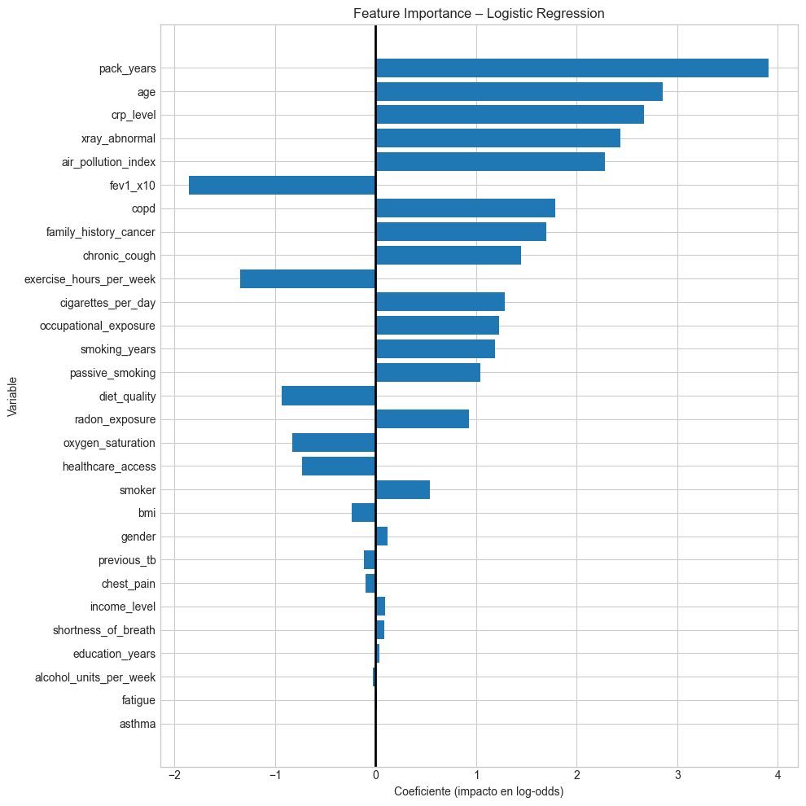

```python
# Obtener coeficientes del modelo
coef = log_model.coef_[0]

# Crear DataFrame de importancias
feature_importance = pd.DataFrame({
    'feature': X_log.columns,
    'coefficient': coef,
    'abs_coefficient': np.abs(coef)
}).sort_values(by='abs_coefficient', ascending=False)

# Plot
plt.figure(figsize=(10, 10))
plt.barh(
    feature_importance['feature'],
    feature_importance['coefficient']
)
plt.axvline(0, color='black', linewidth=2)
plt.gca().invert_yaxis()
plt.title('Feature Importance – Logistic Regression')
plt.xlabel('Coeficiente (impacto en log-odds)')
plt.ylabel('Variable')
plt.tight_layout()
plt.show()
```

En una regresión logística, los coeficientes representan el impacto de cada variable sobre la probabilidad de pertenecer a la clase positiva (`lung_cancer_risk = 1`).

- Coeficientes **positivos** aumentan el riesgo estimado.
- Coeficientes **negativos** disminuyen el riesgo estimado. La magnitud del coeficiente indica la **fuerza de la asociación**, dado que las variables han sido previamente escaladas.

**Variables con contribución positiva (mayor riesgo de cáncer de pulmón)**

**Alta contribución positiva**

- `pack_years`
- `age`
- `crp_level`
- `xray_abnormal`
- `air_pollution_index`

Estas variables son las que más incrementan la probabilidad estimada de cáncer de pulmón. Destaca especialmente `pack_years`, que combina duración e intensidad del tabaquismo, junto a la edad (`age`) ya la inflamación sistémica (`crp_level`) refuerzan la idea de acumulación de daño fisiológico a lo largo de los años. La presencia de anomalías en radiografías (`xray_abnormal`) y la exposición ambiental (`air_pollution_index`) actúan como fuertes indicadores clínicos y ambientales de riesgo.

- Es necesario recordar que ni `age` ni `air_pollution_index` tenían correlación con la variable objetivo (Visto en la sección `2.1`), a pesar de ello, según el modelo entrenado, estas variables son predictores importantes.

**Contribución positiva media**

- `copd`
- `family_history_cancer`
- `chronic_cough`
- `cigarettes_per_day`
- `occupational_exposure`
- `smoking_years`
- `passive_smoking`

Estas variables mantienen una asociación clara con el riesgo, aunque menos intensa que las anteriores. Reflejan condiciones respiratorias crónicas, antecedentes genéticos y exposiciones prolongadas al humo o a entornos laborales nocivos. Su efecto acumulativo puede ser clínicamente relevante incluso si individualmente no son las más dominantes.

**Baja contribución positiva**

- `radon_exposure`
- `smoker`
- `gender`

Aportan información adicional al modelo, pero su impacto marginal es reducido una vez consideradas variables más explicativas como `pack_years` o `crp_level`. En particular, `smoker` (variable binária) pierde peso al estar implícito en variables más informativas relacionadas con intensidad y duración del consumo (variables discretas --> más información)

**Variables con contribución negativa (menor riesgo de cáncer de pulmón)**

**Alta contribución negativa**

- `fev1_x10`
- `exercise_hours_per_week`

Estas variables están fuertemente asociadas con una **reducción del riesgo**. Una mayor función pulmonar (`fev1_x10`) actúa como un potente factor protector, coherente con el análisis previo de regresión lineal. La actividad física regular (`exercise_hours_per_week`) aparece como un indicador indirecto de mejor salud respiratoria y sistémica.

**Contribución negativa media**

- `diet_quality`
- `oxygen_saturation`
- `healthcare_access`

Representan factores de estilo de vida y acceso sanitario que reducen el riesgo estimado. Aunque su efecto no es tan fuerte como el de la función pulmonar, contribuyen de forma consistente a un perfil de menor vulnerabilidad.

- A pesar de no haber encontrado una diferencias estadísticamente ignificativas entre categorias de `diet_quality` y `healthcare_access` en el apartado `2.1`, parece ser que el modelo ha sido capad de encontrar patrones más complejos.

**Baja contribución negativa**

**Conclusión importancia de las variables**

El modelo identifica con claridad tres grandes bloques:

- **Factores de exposición acumulada** (tabaco, edad, contaminación) como principales impulsores del riesgo.
- **Indicadores clínicos objetivos** (CRP elevada, radiografía anormal, FEV1 reducido) como variables altamente informativas.
- **Factores protectores** asociados a buena función pulmonar, estilo de vida saludable y acceso sanitario.

La coherencia entre estos resultados y el conocimiento médico previo refuerza tanto la **validez predictiva** como la **interpretabilidad** del modelo logístico entrenado.

### 2.5 **Regresión Lineal VS Regresión Logística:**

Concretar cuál de los dos modelos es mas idóneo para este conjunto de datos depende del objetivo del estudio. Si el objetivo es establecer relaciones entre variables discretas (ya sea de manera inferencial o predictiva) como se ha hecho en el apartado `2.3` la **Regresión Lineal** es la mejor opción. Por otro lado si el objetivo es tratar de predecir variables binárias, como en este caso la varibale objetivo, como se ha hecho en la sección `2.4`, la **Regresión Logística** es la opción correcta.

A pesar de que ambos modelos tienen el nombre de **regresión**, hay que comprender que cada una se usa en un contexto diferente, son herramientas para distintos problemas. Dependiendo de que tipo de problema sea el objetivo del proyecto se deberan usar unas herramientas u otras.

## PARTE 3: Regresión Lineal "From Scratch" (Datos Simulados)

**Objetivo:** Demostrar que entiendes la matemática detrás de `LinearRegression()` implementándola con NumPy.

Amplia con:

- **Predicción y evaluación** Utiliza tu implementación para:
  - Realizar predicciones
  - Calcular manualmente el **MSE** y el **R²**, sin usar funciones de Scikit-Learn.
- **Comparación con Scikit-Learn** Entrena un modelo `LinearRegression()` sobre los mismos datos y compara:
  - Coeficientes
  - Métricas de evaluación  
    Discute posibles diferencias numéricas.

|  | Modelos | Intercepto (b) | Pendiente estimada | Error (MSE) | Varianza expicada (R_Squared) |
| --- | --- | --- | --- | --- | --- |
| 0 | Tu Modelo | 4.108776 | 2.862956 | 0.810211 | 0.768236 |
| 1 | Modelo Scikit-Learn | 4.215096 | 2.770113 | 0.806585 | 0.769274 |

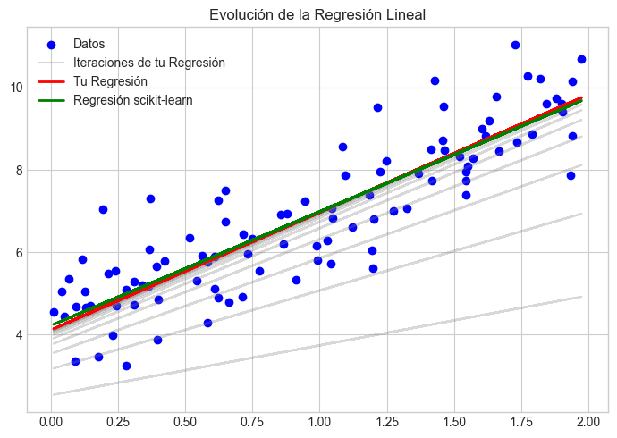

```python
# --- NO TOCAR: GENERACIÓN DE DATOS ---
np.random.seed(42)
X_mock = 2 * np.random.rand(100, 1)
y_mock = 4 + 3 * X_mock + np.random.randn(100, 1)
# -----------------------------------

def evolve_linear_regression(X, y, iteraciones=16, eta=0.1):
    """
    Calcula la pendiente (w), el intercepto (beta_0),
    el error MSE (mse) y R^2 (r_squared)
    usando las fórmulas de OLS con NumPy.
    Returns: (b, w, b_history, w_history, mse_history, r_squared_history)
    """

    # TU CÓDIGO AQUÍ
    #Generacion aleatoria de parametros (numpy)
    w = np.random.randn()
    b = np.random.randn()

    n = len(X)

    #Arrays vacios para almacenar los parámetros y error en cada iteración
    w_history = []
    b_history = []
    mse_history = []
    r2_history = []

    #Total Sum of Squares (TSS) constante
    tss = np.sum((y - np.mean(y)) ** 2)

    for i in range(iteraciones):
        #Calcular valor predecido y error (valor real - predecido)
        y_pred = b + w * X
        error = y - y_pred

        #Calculo derivadas de descenso de gradiente
        dw = (-2 / n) * np.sum(X * error)
        db = (-2 / n) * np.sum(error)

        #Ajustar parametros mediante el método de descenso de gradiente y learning rate (eta)
        w = w - eta * dw
        b = b - eta * db

        # MSE
        mse = np.mean(error ** 2)

        # R_squared
        rss = np.sum(error ** 2)
        r2 = 1 - rss / tss

        #Guardar cálculos
        w_history.append(w)
        b_history.append(b)
        mse_history.append(mse)
        r2_history.append(r2)

    return b, w, b_history, w_history, mse_history, r2_history


# Ejecutamos el modelo
b, w, b_hist, w_hist, mse_history, r2_history = evolve_linear_regression(X_mock, y_mock)


# Modelo Scikit-Learn copn los mismos datos
lr_model = LinearRegression()
lr_model.fit(X_mock, y_mock)

# Parámetros del modelo de Scikit-Learn
b_sklearn = lr_model.intercept_[0]
w_sklearn = lr_model.coef_[0][0]

# Predicciones del modelo de Scikit-Learn
y_pred_sklearn = lr_model.predict(X_mock)

# Métricas del modelo de Scikit -Learn
mse_sklearn = mean_squared_error(y_mock, y_pred_sklearn)
r2_sklearn = r2_score(y_mock, y_pred_sklearn)

# Creación de un DataFrame para visualizar mejor la comparación entre las dos regresiones
regresiones = pd.DataFrame({'Modelos':['Tu Modelo', 'Modelo Scikit-Learn'],
        'Intercepto (b)':[b, b_sklearn],
        'Pendiente estimada':[w, w_sklearn],
        'Error (MSE)': [mse_history[-1], mse_sklearn],
        'Varianza expicada (R_Squared)':[r2_history[-1], r2_sklearn]})

display(regresiones)

#Visualización
plt.figure(figsize=(7, 5))
plt.scatter(X_mock, y_mock, color='blue', label='Datos')

# Rectas intermedias
c = 0
for bi, wi in zip(b_hist[:-1], w_hist[:-1]):
    if c==0:
        plt.plot(X_mock, bi + wi * X_mock, color='gray', alpha=0.3, label='Iteraciones de tu Regresión')
        c=1
    else:
        plt.plot(X_mock, bi + wi * X_mock, color='gray', alpha=0.3)

# Recta final manual vs LinearRegression() de Scikit-Learn
plt.plot(X_mock, b + w * X_mock, color='red', linewidth=2, label='Tu Regresión')
plt.plot(X_mock, y_pred_sklearn, color='green', linewidth=2, label='Regresión scikit-learn')
plt.title('Evolución de la Regresión Lineal')
plt.legend()

plt.tight_layout()
plt.show()
```

Los resultados obtenidos por ambos modelos son muy similares, tanto en los parámetros estimados como en las métricas de ajuste:

Las pequeñas discrepancias entre valores son esperables y se explican por el **método de optimización empleado** en cada enfoque.

**`Modelo Manual` (Descenso de Gradiente)**

- Se basa en un **proceso iterativo**.
- La solución final depende de:
  - el número de iteraciones,
  - la tasa de aprendizaje, *learning rate* (η),
  - los valores iniciales aleatorios de los parámetros.
- Si el algoritmo no alcanza una convergencia completa, los coeficientes obtenidos son una **aproximación** al mínimo del error.

Por otro lado el modelo de **`LinearRegression` de Scikit-Learn**

- Utiliza una **solución cerrada (Ordinary Least Squares)**, no iterativa.
- Calcula directamente el **mínimo global exacto** del error cuadrático (Cálculo matricial).

Como consecuencia, los resultados son **más estables, deterministas y reproducibles**.

En general la solución que implementa el modelo de `LinearRegression` es más segura, ya que no depende de parámetros como el *learning rate* el cual puede hacer que nunca se encuentre la solución exacta cuando esta existe.  
La principal desventaja de este método es que es más costoso computacionalmente, ya que se basa en cálculos matriciales.

Scikit-learn proporciona una alternativa iterativa al modelo clásico:

```
- from sklearn.linear_model import SGDRegressor
```

## PARTE 4: Series Temporales (Datos Simulados)

**Objetivo:** Analizar tendencias y estacionalidad en una serie temporal generada.

**Tareas:**

1. Convierte el índice a formato DateTime.
2. Haz un resampleo mensual (`'M'`) mostrando la media de ventas.
3. Calcula una **Media Móvil** de 3 meses para suavizar la curva.
4. Usa `seasonal_decompose` para visualizar los componentes (Tendencia, Estacionalidad y ruido).

Amplia Con:

- **Generación de la serie** Describe brevemente cómo se ha generado la serie temporal simulada, indicando si incluye tendencia, estacionalidad y ruido.
- **Comparación de suavizados** Calcula una segunda media móvil con una ventana distinta y compara visualmente ambos suavizados. Comenta las diferencias observadas.

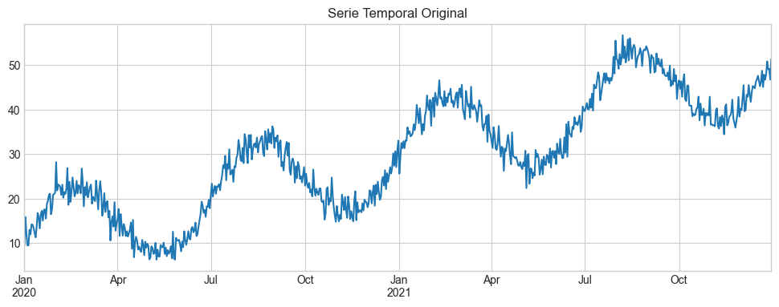

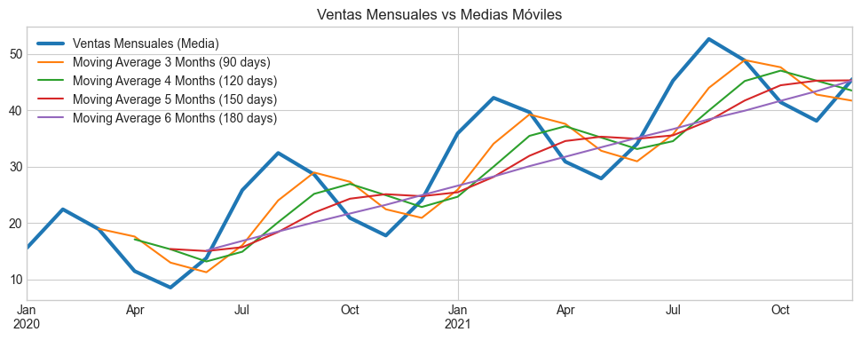

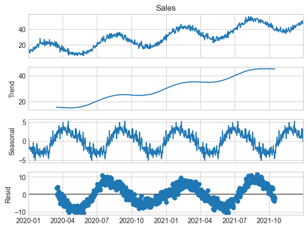

```python
# --- NO TOCAR: GENERACIÓN DE DATOS TEMPORALES ---
dates = pd.date_range(start='2020-01-01', periods=365*2, freq='D')
values = np.linspace(10, 50, len(dates)) + 10 * np.sin(np.linspace(0, 3.14*8, len(dates))) + np.random.normal(0, 2, len(dates))
ts_df = pd.DataFrame({'Sales': values}, index=dates)
# -----------------------------------------------

# TU CÓDIGO AQUÍ

# 1. Plot inicial
ts_df['Sales'].plot(title='Serie Temporal Original', figsize=(12,4))
plt.show()

# 2. Resampleo Mensual
monthly_sales = ts_df['Sales'].resample('M').mean()
monthly_sales.plot(label = 'Ventas Mensuales (Media)', linewidth = 3, figsize=(12,4))

# 3. Media Móvil (3 Meses vs 4 Meses)
ts_df['Moving_Avg_3M'] = ts_df['Sales'].rolling(window = 90).mean()
ts_df['Moving_Avg_4M'] = ts_df['Sales'].rolling(window = 120).mean()
ts_df['Moving_Avg_5M'] = ts_df['Sales'].rolling(window = 150).mean()
ts_df['Moving_Avg_6M'] = ts_df['Sales'].rolling(window = 180).mean()

monthly_3m = monthly_sales.rolling(window=3).mean()
monthly_3m.plot(label = 'Moving Average 3 Months (90 days)')
monthly_4m = monthly_sales.rolling(window=4).mean()
monthly_4m.plot(label = 'Moving Average 4 Months (120 days)')
monthly_5m = monthly_sales.rolling(window=5).mean()
monthly_5m.plot(label = 'Moving Average 5 Months (150 days)')
monthly_6m = monthly_sales.rolling(window=6).mean()
monthly_6m.plot(label = 'Moving Average 6 Months (180 days)')


#ts_df['Moving_Avg_3M'].plot(linewidth = 2, label='Moving Average 3 Months (90 days)')
#ts_df['Moving_Avg_4M'].plot(linewidth = 2, label='Moving Average 4 Months (120 days)')
#ts_df['Moving_Avg_5M'].plot(linewidth = 2, label='Moving Average 5 Months (150 days)')
#ts_df['Moving_Avg_6M'].plot(linewidth = 2, label='Moving Average 6 Months (180 days)')
plt.legend()
plt.title('Ventas Mensuales vs Medias Móviles')
plt.show()

# 4. Descomposición
result = seasonal_decompose(ts_df['Sales'], model='additive', period=150)
result.plot()
plt.show()
```

La serie presenta una tendencia creciente clara a lo largo del tiempo, combinada con un patrón estacional periódico y ruido aleatorio. Esto es típico de procesos reales como ventas, demanda o actividad económica, donde existe crecimiento estructural y ciclos repetitivos superpuestos. El resampleo mensual mediante resample('M').mean() suaviza el ruido diario y permite observar mejor la evolución global y los ciclos de mayor escala.

Utilidad de las medias móviles (moving averages) Las medias móviles se utilizan para suavizar fluctuaciones de corto plazo y resaltar patrones subyacentes:

**Ventanas cortas (3 meses / 90 días)**

- Reaccionan rápidamente a cambios recientes. Más sensibles al ruido.
- Útiles para detección temprana de cambios, monitoring operativo o análisis de corto plazo.

**Ventanas intermedias (4–5 meses / 120–150 días)**

- Buen equilibrio entre suavizado y capacidad de respuesta.
- Adecuadas para análisis exploratorio y seguimiento de la tendencia real.

**Ventanas largas (6 meses / 180 días)**

- Eliminan gran parte del ruido y de la estacionalidad.
- Útiles para análisis estratégico, planificación a largo plazo o comparación de ciclos amplios.
- A más grande la ventana más lag se introduce, haciendo que la tendencia reaccione más tarde a cambios bruscos.

La elección del periodo depende del objetivo: detección rápida vs estabilidad de la señal.

La descomposición mediante seasonal_decompose() permite separar la señal observada en componentes interpretables, facilitando el análisis, la modelización y el diagnóstico de la serie. Es especialmente útil para:

- Identificar si la estacionalidad es estable.
- Analizar la tendencia sin interferencia del ruido.
- Verificar si los residuos contienen estructura no explicada.

**Relación entre medias móviles y descomposición**

Las medias móviles son una aproximación empírica para aislar la tendencia, mientras que la descomposición formal separa explícitamente los componentes. En la práctica:

- Las medias móviles son rápidas y útiles para exploración.
- La descomposición es más potente para análisis estructural, forecasting y validación de supuestos en modelos temporales.